# Inference for Regression

February 13, 2018

## Some theoretical concerns

The coefficients in a linear regression are given by: \[\hat{\beta}_0 = \bar{y}-\hat{\beta_1} \bar{x}\]

\[\hat{\beta}_1 = \frac{\sum_{i=1}^n (x_i-\bar{x})(y_i-\bar{y})}{\sum_{i=1}^n (x_i-\bar{x})^2}\]

Show that:

- \((\bar{x}, \bar{y})\) is on the regression line
- \(\sum y_i-\hat{y}_i=0\)

## Inference for Regression Slope (2.1)

## A slight detour - t-tests

Loaded dplyr and cdc dataset:

```r
cdc %>% t.test(height~exerany, data=.)
```

```
##
##  Welch Two Sample t-test
##
## data:  height by exerany
## t = -16.016, df = 8806.3, p-value < 2.2e-16
## alternative hypothesis: true difference in means is not equal to 0
## 95 percent confidence interval:
##  -1.195959 -0.935137
## sample estimates:
## mean in group 0 mean in group 1
##        66.38832        67.45387
```

## Regression version

```r
cdc %>% lm(height~exerany, data=.) %>% summary()
```

```
##
## Call:
## lm(formula = height ~ exerany, data = .)
##
## Residuals:
##      Min       1Q   Median       3Q      Max
## -19.4539  -3.3883  -0.3883   3.5461  25.5461
##
## Coefficients:
##             Estimate Std. Error t value Pr(>|t|)
## (Intercept) 66.38832    0.05749 1154.81   <2e-16 ***
## exerany      1.06555    0.06657   16.01   <2e-16 ***
## ---
## Signif. codes:  0 '***' 0.001 '**' 0.01 '*' 0.05 '.' 0.1 ' ' 1
##
## Residual standard error: 4.1 on 19998 degrees of freedom
## Multiple R-squared:  0.01265,    Adjusted R-squared:  0.0126
## F-statistic: 256.2 on 1 and 19998 DF,  p-value: < 2.2e-16
```

## What’s going on?

Regression: \(\widehat{height} = 66.38832+1.06555*\textrm{exerany}\)

Whether the slope is “meaningful” is the same question as whether there’s a difference between groups. (That’s a t-test)

Recall a 2-sample t-test: \[t = \frac{\hat{x_1}-\hat{x_2}}{\sqrt{\frac{s_1^2}{n_1}+\frac{s_2^2}{n_2}}} = \frac{\textrm{diff of means}}{\textrm{std error}}\]

## The Continuous Case

```r
cdc %>% lm(height~age, data=.) %>% summary()
```

```
##
## Call:
## lm(formula = height ~ age, data = .)
##
## Residuals:
##     Min      1Q  Median      3Q     Max
## -19.696  -3.125  -0.245   3.146  25.395
##
## Coefficients:
##              Estimate Std. Error t value Pr(>|t|)
## (Intercept) 68.536818   0.081214  843.91   <2e-16 ***
## age         -0.030042   0.001684  -17.84   <2e-16 ***
## ---
## Signif. codes:  0 '***' 0.001 '**' 0.01 '*' 0.05 '.' 0.1 ' ' 1
##
## Residual standard error: 4.094 on 19998 degrees of freedom
## Multiple R-squared:  0.01567,    Adjusted R-squared:  0.01562
## F-statistic: 318.4 on 1 and 19998 DF,  p-value: < 2.2e-16
```

## The values

\(t = \frac{\hat{\beta_1}}{SE_{\hat{\beta_1}}}\)

IMPORTANT: STANDARD ERROR OF SLOPE \(SE_{\hat{\beta_1}}\) \(\neq\) STANDARD ERROR OF REGRESSION \(\hat{\sigma}_\epsilon\)

\[\widehat{\sigma_\epsilon} = \sqrt{\frac{SSE}{n-2}}, \ SE_{\hat{\beta_1}} = \sqrt{\frac{\sum (y_i - \hat{y}_i)^2 /(n-2)}{\sum (x_i - \bar{x})^2}}\]

## The formal test

Using conditions/assumptions for simple linear model:

\(H_0: \beta_1 = 0\)

\(H_A: \beta_1 \neq 0\)

With test statistic \(t = \frac{\hat{\beta_1}}{SE_\hat{\beta_1}}\), \(n-2\) degrees of freedom

## Asides

- You can do a 1-tailed test, but this isn’t typically done in regression
- You can remove the intercept (\(y = \beta_1*x + \epsilon\)) but you should have a good reason to do so
- You can do a similar test for intercept, though it is usually less interesting. The slope is usually where the interesting stuff is happening

## Question

The standard deviation of the error or regression standard error, \(\widehat{\sigma_\epsilon}\), isn’t *quite* the “average of the errors.” Why?

## Confidence Intervals

```r
cdc %>% t.test(height~exerany, data=.)
```

```
##
##  Welch Two Sample t-test
##
## data:  height by exerany
## t = -16.016, df = 8806.3, p-value < 2.2e-16
## alternative hypothesis: true difference in means is not equal to 0
## 95 percent confidence interval:
##  -1.195959 -0.935137
## sample estimates:
## mean in group 0 mean in group 1
##        66.38832        67.45387
```

```r
cdc %>% lm(height~exerany, data=.) %>% summary()
```

```
##
## Call:
## lm(formula = height ~ exerany, data = .)
##
## Residuals:
##      Min       1Q   Median       3Q      Max
## -19.4539  -3.3883  -0.3883   3.5461  25.5461
##
## Coefficients:
##             Estimate Std. Error t value Pr(>|t|)
## (Intercept) 66.38832    0.05749 1154.81   <2e-16 ***
## exerany      1.06555    0.06657   16.01   <2e-16 ***
## ---
## Signif. codes:  0 '***' 0.001 '**' 0.01 '*' 0.05 '.' 0.1 ' ' 1
##
## Residual standard error: 4.1 on 19998 degrees of freedom
## Multiple R-squared:  0.01265,    Adjusted R-squared:  0.0126
## F-statistic: 256.2 on 1 and 19998 DF,  p-value: < 2.2e-16
```

## Formulas

To get \(t^*\):

```r
qt(.975, 19998)
```

```
## [1] 1.960083
```

## ANOVA (2.2)

## How it works

Analysis of variance is all about splitting up variation in Y between the model and the residuals. We’ll walk through the equations in the section.

\(y - \bar{y} = (\hat{y}-\bar{y}) + (y - \hat{y})\) (model and residual)

ANOVA sum of squares identity:

\(\sum (y - \bar{y})^2 = \sum (\hat{y} - \bar{y})^2 + \sum(y - \hat{y})^2\)

(this is not obvious)

SSTotal = SSModel + SSE

## What’s going on?

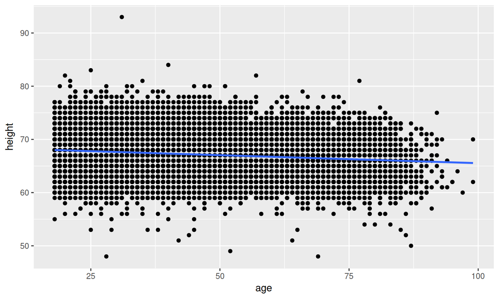

```r
cdc %>% qplot(age, height, data=.) + geom_smooth(method="lm", se=F)
```

## Example

```r
mod1 <- lm(height~age, data=cdc)
summary(mod1)
```

```
##
## Call:
## lm(formula = height ~ age, data = cdc)
##
## Residuals:
##     Min      1Q  Median      3Q     Max
## -19.696  -3.125  -0.245   3.146  25.395
##
## Coefficients:
##              Estimate Std. Error t value Pr(>|t|)
## (Intercept) 68.536818   0.081214  843.91   <2e-16 ***
## age         -0.030042   0.001684  -17.84   <2e-16 ***
## ---
## Signif. codes:  0 '***' 0.001 '**' 0.01 '*' 0.05 '.' 0.1 ' ' 1
##
## Residual standard error: 4.094 on 19998 degrees of freedom
## Multiple R-squared:  0.01567,    Adjusted R-squared:  0.01562
## F-statistic: 318.4 on 1 and 19998 DF,  p-value: < 2.2e-16
```

```r
mod1 <- lm(height~age, data=cdc)
anova(mod1)
```

```
## Analysis of Variance Table
##
## Response: height
##              Df Sum Sq Mean Sq F value    Pr(>F)
## age           1   5335  5335.1  318.37 < 2.2e-16 ***
## Residuals 19998 335118    16.8
## ---
## Signif. codes:  0 '***' 0.001 '**' 0.01 '*' 0.05 '.' 0.1 ' ' 1
```

Can also do:

`cdc %>% lm(height~age, data=.) %>% anova()`

if you want to use pipes

## Interpreting

How do we interpret this table?

## Drawing distributions

This isn’t *necessary*, but it’s cool.

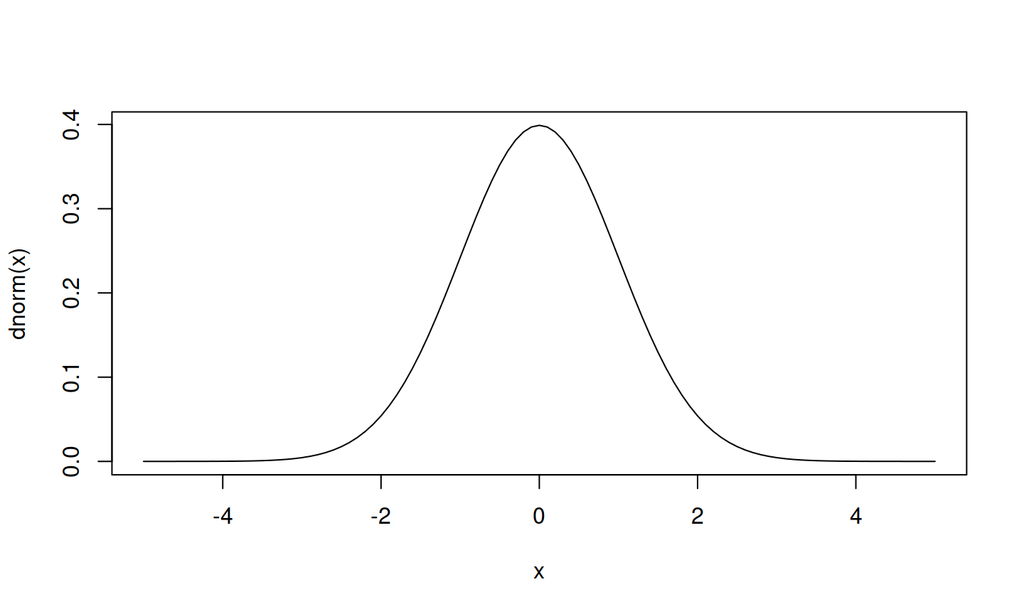

```r
curve(dnorm(x),-5,5)
```

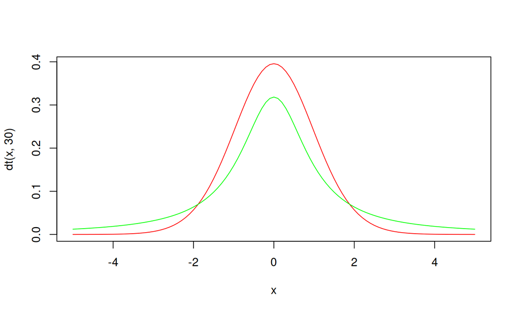

```r
curve(dt(x,30),-5,5,col="red")
curve(dt(x,1),-5,5, add=TRUE, col="green")
```

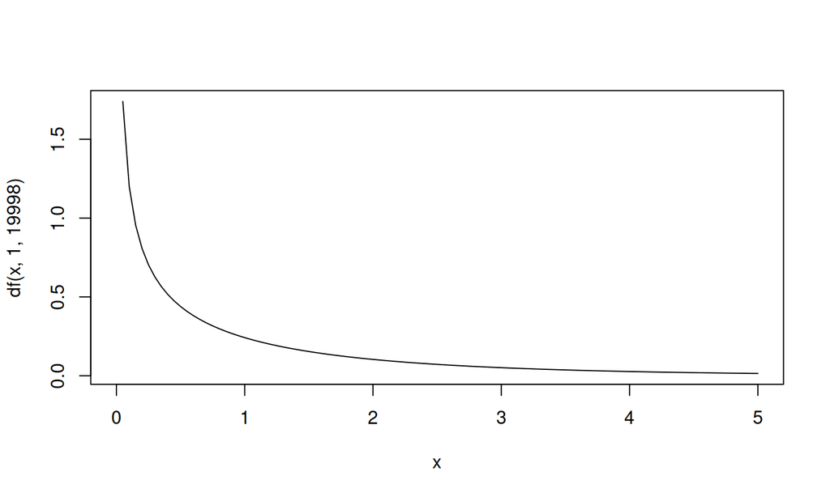

```r
curve(df(x,1,19998),0,5)
```

## Try this on your data set for lab 0

## Correlation (2.3)

## The values of interest

Coefficient of determination: \(r^2\)

Correlation coefficient: \(r\)

## Definitions

\[r^2 = \frac{\sum (\hat{y}-\bar{y})^2}{\sum (y - \bar{y})^2} = \frac{SSModel}{SSTotal}\]

What values can \(r^2\) be?

\[\hat{\beta_1} = r \frac{s_Y}{s_X}\]

What values can \(r\) be?

## t-test for correlation

Let \(\rho\) be the correlation. What is the null hypothesis? What is the alternative hypothesis?

Assuming conditions for the simple linear model hold, \[t = \frac{r \sqrt{n-2}}{\sqrt{1-r^2}}, \ df=n-2\]

## Making sense of this:

Let’s use the goldenrod data

```r
Goldenrod
```

```
## # A tibble: 1,055 x 9
##    Gdiam03 Stdiam03 Wall03 Fate03 Gdiam04 Stdiam04 Wall04 Fate04 Fly04
##      <dbl>    <dbl>  <dbl> <chr>    <dbl>    <dbl>  <dbl> <chr>  <chr>
##  1    20.7     3.00   6.00 f         18.9     3.00  NA    e      n
##  2    21.7     3.60   7.30 f         23.1     3.70   9.40 f      y
##  3    20.5     3.50   7.80 f         19.4     3.90   6.60 b      n
##  4    15.0     5.10  NA    e         21.8     3.00  10.0  f      y
##  5    19.5     3.90   7.10 u         23.5     3.50   9.20 f      y
##  6    18.1     4.70   7.10 b         22.6     3.50   7.80 f      y
##  7    23.0     4.90   8.60 f         11.6     4.50   4.30 f      y
##  8    26.5     4.80  10.5  f         25.2     4.50   9.60 b      n
##  9    13.8     3.70  NA    e         26.5     6.90  11.3  b      n
## 10    21.5     4.80  10.0  u         20.5     5.00  NA    e      n
## # ... with 1,045 more rows
```

## Linear model for ’04

```r
Goldenrod %>% lm(Wall04~Gdiam04, data=.) %>% summary()
```

```
##
## Call:
## lm(formula = Wall04 ~ Gdiam04, data = .)
##
## Residuals:
##     Min      1Q  Median      3Q     Max
## -7.2532 -0.9528 -0.0842  0.8632  5.5731
##
## Coefficients:
##             Estimate Std. Error t value Pr(>|t|)
## (Intercept) -0.84500    0.35765  -2.363   0.0183 *
## Gdiam04      0.36317    0.01719  21.124   <2e-16 ***
## ---
## Signif. codes:  0 '***' 0.001 '**' 0.01 '*' 0.05 '.' 0.1 ' ' 1
##
## Residual standard error: 1.608 on 940 degrees of freedom
##   (113 observations deleted due to missingness)
## Multiple R-squared:  0.3219, Adjusted R-squared:  0.3212
## F-statistic: 446.2 on 1 and 940 DF,  p-value: < 2.2e-16
```

## Correlation

```r
cor.test(Goldenrod$Wall04,Goldenrod$Gdiam04)
```

```
##
##  Pearson's product-moment correlation
##
## data:  Goldenrod$Wall04 and Goldenrod$Gdiam04
## t = 21.124, df = 940, p-value < 2.2e-16
## alternative hypothesis: true correlation is not equal to 0
## 95 percent confidence interval:
##  0.5224105 0.6091516
## sample estimates:
##       cor
## 0.5673528
```

## What happens if you switch the two variables?

(Be careful of syntax)

## Github in groups

## Intervals for Prediction (2.4)

## Confidence intervals for regression

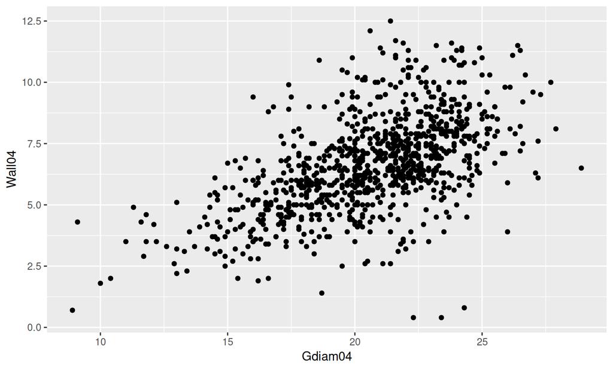

```r
Goldenrod %>% qplot(Gdiam04, Wall04, data=.)
```

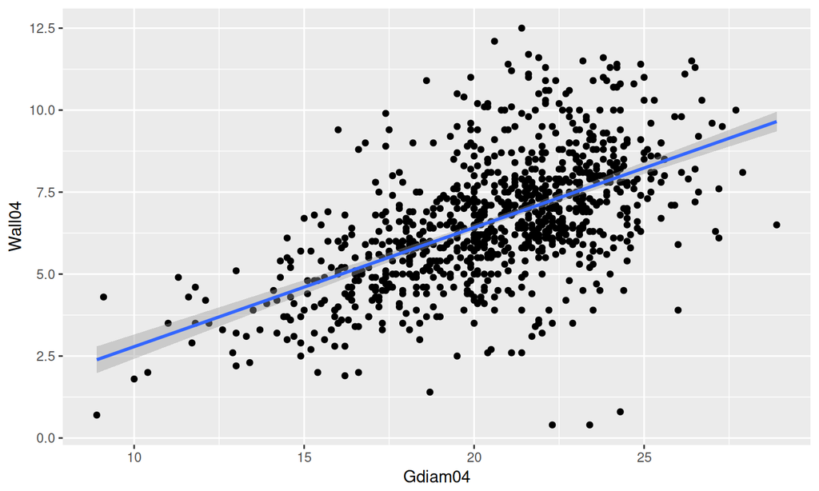

```r
Goldenrod %>% qplot(Gdiam04, Wall04, data=.)+geom_smooth(method="lm")
```

## Why the band?

A confidence interval for the mean response \(\mu_Y\) when X takes on the value \(x^*\) is: \[\hat{y} \pm t^* \cdot SE_{\hat{\mu}}\] where \[SE_{\hat{\mu}} = \hat{\sigma_\epsilon} \sqrt{\frac{1}{n}+\frac{(x^*-\bar{x})^2}{\sum (x - \bar{x})^2}}\] Which then has prediction interval for a single observation of Y when X takes on the value \(x^*\): \[\hat{y} \pm t^* SE_{\hat{y}}\] Where \[SE_\hat{y} = \hat{\sigma_\epsilon} \sqrt{1+\frac{1}{n}+\frac{(x^*-\bar{x})^2}{\sum (x - \bar{x})^2}}\]